# DATA621 - Wine

Daniel Hong, Mauricio Alarcon, Maxwell Wagner

Nov 15, 2016

## 1. DATA EXPLORATION (25 Points)

Describe the size and the variables in the insurance training data set. Consider that too much detail will cause a manager to lose interest while too little detail will make the manager consider that you arenât doing your job. Some suggestions are given below. Please do NOT treat this as a check list of things to do to complete the assignment. You should have your own thoughts on what to tell the boss. These are just ideas.

1. Mean / Standard Deviation / Median
2. Bar Chart or Box Plot of the data
3. Is the data correlated to the target variable (or to other variables?)
4. Are any of the variables missing and need to be imputed âfixedâ?
1. Mean / Standard Deviation / Median

```r
require("plyr")
require("knitr")
require("psych")
# Let's load the data

training <- read.csv(url('https://raw.githubusercontent.com/rmalarc/DATA621/master/hw05/wine-training-data.csv'),stringsAsFactors = FALSE)
metadata <- read.csv(url('https://raw.githubusercontent.com/rmalarc/DATA621/master/hw05/wine-metadata.csv'))
colnames(metadata) <- c("Variable", "Name Definition", "Theoretical Effect")
evaluation <- read.csv(url('https://raw.githubusercontent.com/rmalarc/DATA621/master/hw05/wine-evaluation-data.csv'),stringsAsFactors = FALSE)

kable(metadata)
```

| Variable | Name Definition | Theoretical Effect |
| --- | --- | --- |
| INDEX | Identification Variable (do not use) | None |
| TARGET | Number of Cases Purchased | None |
| AcidIndex | Proprietary method of testing total acidity of wine by using a weighted average |  |
| Alcohol | Alcohol Content |  |
| Chlorides | Chloride content of wine |  |
| CitricAcid | Citric Acid Content |  |
| Density | Density of Wine |  |
| FixedAcidity | Fixed Acidity of Wine |  |
| FreeSulfurDioxide | Sulfur Dioxide content of wine |  |
| LabelAppeal | Marketing Score indicating the appeal of label design for consumers. High numbers suggest customers like the label design. Negative numbers suggest customes don’t like the design. | Many consumers purchase based on the visual appeal of the wine label design. Higher numbers suggest better sales. |
| ResidualSugar | Residual Sugar of wine |  |
| STARS Wine rating by a team of experts. 4 Stars = Excellent, 1 Star = Poor | A high number of stars suggests high sales |  |
| Sulphates | Sulfate conten of wine |  |
| TotalSulfurDioxide | Total Sulfur Dioxide of Wine |  |
| VolatileAcidity | Volatile Acid content of wine |  |
| pH | pH of wine |  |

```r
columns <- colnames(training)
target <- "TARGET"
inputs <- columns[!columns %in% c(target,"INDEX")]


summary <- describe(training[,c(target,inputs)],na.rm = TRUE)[,c("n","mean","sd","median","min","max")]
summary$completeness <- summary$n/nrow(training)
summary$cv <- 100*summary$sd/summary$mean

kable(summary)
```

|  | n | mean | sd | median | min | max | completeness | cv |
| --- | --- | --- | --- | --- | --- | --- | --- | --- |
| TARGET | 12795 | 3.0290739 | 1.9263682 | 3.00000 | 0.00000 | 8.00000 | 1.0000000 | 63.595948 |
| ï..INDEX | 12795 | 8069.9803048 | 4656.9051071 | 8110.00000 | 1.00000 | 16129.00000 | 1.0000000 | 57.706524 |
| FixedAcidity | 12795 | 7.0757171 | 6.3176435 | 6.90000 | -18.10000 | 34.40000 | 1.0000000 | 89.286264 |
| VolatileAcidity | 12795 | 0.3241039 | 0.7840142 | 0.28000 | -2.79000 | 3.68000 | 1.0000000 | 241.902095 |
| CitricAcid | 12795 | 0.3084127 | 0.8620798 | 0.31000 | -3.24000 | 3.86000 | 1.0000000 | 279.521529 |
| ResidualSugar | 12179 | 5.4187331 | 33.7493790 | 3.90000 | -127.80000 | 141.15000 | 0.9518562 | 622.827856 |
| Chlorides | 12157 | 0.0548225 | 0.3184673 | 0.04600 | -1.17100 | 1.35100 | 0.9501368 | 580.906303 |
| FreeSulfurDioxide | 12148 | 30.8455713 | 148.7145577 | 30.00000 | -555.00000 | 623.00000 | 0.9494334 | 482.126125 |
| TotalSulfurDioxide | 12113 | 120.7142326 | 231.9132105 | 123.00000 | -823.00000 | 1057.00000 | 0.9466979 | 192.117537 |
| Density | 12795 | 0.9942027 | 0.0265376 | 0.99449 | 0.88809 | 1.09924 | 1.0000000 | 2.669239 |
| pH | 12400 | 3.2076282 | 0.6796871 | 3.20000 | 0.48000 | 6.13000 | 0.9691286 | 21.189709 |
| Sulphates | 11585 | 0.5271118 | 0.9321293 | 0.50000 | -3.13000 | 4.24000 | 0.9054318 | 176.837114 |
| Alcohol | 12142 | 10.4892363 | 3.7278190 | 10.40000 | -4.70000 | 26.50000 | 0.9489644 | 35.539471 |
| LabelAppeal | 12795 | -0.0090660 | 0.8910892 | 0.00000 | -2.00000 | 2.00000 | 1.0000000 | -9828.868025 |
| AcidIndex | 12795 | 7.7727237 | 1.3239264 | 8.00000 | 4.00000 | 17.00000 | 1.0000000 | 17.032979 |
| STARS | 9436 | 2.0417550 | 0.9025400 | 2.00000 | 1.00000 | 4.00000 | 0.7374756 | 44.204131 |

```r
head(training)
```

```
##   ï..INDEX TARGET FixedAcidity VolatileAcidity CitricAcid ResidualSugar
## 1        1      3          3.2           1.160      -0.98          54.2
## 2        2      3          4.5           0.160      -0.81          26.1
## 3        4      5          7.1           2.640      -0.88          14.8
## 4        5      3          5.7           0.385       0.04          18.8
## 5        6      4          8.0           0.330      -1.26           9.4
## 6        7      0         11.3           0.320       0.59           2.2
##   Chlorides FreeSulfurDioxide TotalSulfurDioxide Density   pH Sulphates
## 1    -0.567                NA                268 0.99280 3.33     -0.59
## 2    -0.425                15               -327 1.02792 3.38      0.70
## 3     0.037               214                142 0.99518 3.12      0.48
## 4    -0.425                22                115 0.99640 2.24      1.83
## 5        NA              -167                108 0.99457 3.12      1.77
## 6     0.556               -37                 15 0.99940 3.20      1.29
##   Alcohol LabelAppeal AcidIndex STARS
## 1     9.9           0         8     2
## 2      NA          -1         7     3
## 3    22.0          -1         8     3
## 4     6.2          -1         6     1
## 5    13.7           0         9     2
## 6    15.4           0        11    NA
```

```r
summary(training)
```

```
##     ï..INDEX         TARGET       FixedAcidity     VolatileAcidity
##  Min.   :    1   Min.   :0.000   Min.   :-18.100   Min.   :-2.7900
##  1st Qu.: 4038   1st Qu.:2.000   1st Qu.:  5.200   1st Qu.: 0.1300
##  Median : 8110   Median :3.000   Median :  6.900   Median : 0.2800
##  Mean   : 8070   Mean   :3.029   Mean   :  7.076   Mean   : 0.3241
##  3rd Qu.:12106   3rd Qu.:4.000   3rd Qu.:  9.500   3rd Qu.: 0.6400
##  Max.   :16129   Max.   :8.000   Max.   : 34.400   Max.   : 3.6800
##
##    CitricAcid      ResidualSugar        Chlorides       FreeSulfurDioxide
##  Min.   :-3.2400   Min.   :-127.800   Min.   :-1.1710   Min.   :-555.00
##  1st Qu.: 0.0300   1st Qu.:  -2.000   1st Qu.:-0.0310   1st Qu.:   0.00
##  Median : 0.3100   Median :   3.900   Median : 0.0460   Median :  30.00
##  Mean   : 0.3084   Mean   :   5.419   Mean   : 0.0548   Mean   :  30.85
##  3rd Qu.: 0.5800   3rd Qu.:  15.900   3rd Qu.: 0.1530   3rd Qu.:  70.00
##  Max.   : 3.8600   Max.   : 141.150   Max.   : 1.3510   Max.   : 623.00
##                    NA's   :616        NA's   :638       NA's   :647
##  TotalSulfurDioxide    Density             pH          Sulphates
##  Min.   :-823.0     Min.   :0.8881   Min.   :0.480   Min.   :-3.1300
##  1st Qu.:  27.0     1st Qu.:0.9877   1st Qu.:2.960   1st Qu.: 0.2800
##  Median : 123.0     Median :0.9945   Median :3.200   Median : 0.5000
##  Mean   : 120.7     Mean   :0.9942   Mean   :3.208   Mean   : 0.5271
##  3rd Qu.: 208.0     3rd Qu.:1.0005   3rd Qu.:3.470   3rd Qu.: 0.8600
##  Max.   :1057.0     Max.   :1.0992   Max.   :6.130   Max.   : 4.2400
##  NA's   :682                         NA's   :395     NA's   :1210
##     Alcohol       LabelAppeal          AcidIndex          STARS
##  Min.   :-4.70   Min.   :-2.000000   Min.   : 4.000   Min.   :1.000
##  1st Qu.: 9.00   1st Qu.:-1.000000   1st Qu.: 7.000   1st Qu.:1.000
##  Median :10.40   Median : 0.000000   Median : 8.000   Median :2.000
##  Mean   :10.49   Mean   :-0.009066   Mean   : 7.773   Mean   :2.042
##  3rd Qu.:12.40   3rd Qu.: 1.000000   3rd Qu.: 8.000   3rd Qu.:3.000
##  Max.   :26.50   Max.   : 2.000000   Max.   :17.000   Max.   :4.000
##  NA's   :653                                          NA's   :3359
```

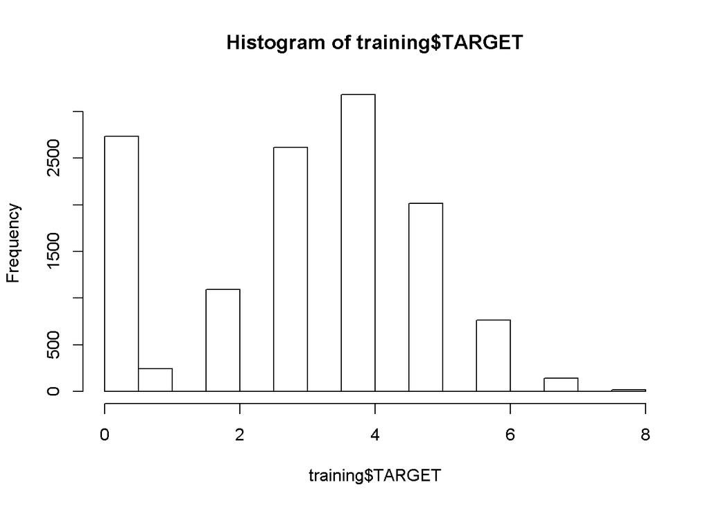

```r
hist(training$TARGET)
```

```r
# Missing Column Analysis
missing_data <- rownames( summary[summary$completeness<1,])

z.test <- function(a, mu, var){
   zeta = (mean(a) - mu) / (sqrt(var / length(a)))
   return(zeta)
}

mda <- lapply(missing_data, function(c) {
  missing <- training[is.na(training[,c]),target]
  not_missing <- training[!is.na(training[,c]),target]
  missing_mean_z <- z.test(missing,mean(not_missing),var(not_missing))
  missing_mean_p <- 2*pnorm(-abs(missing_mean_z))
  data.frame(variable=c,target_mean_missing=mean(missing),target_mean_not_missing=mean(not_missing),target_mean_missing_z_score=missing_mean_z,missing_mean_p)
})

kable(do.call(rbind,mda))
```

| variable | target_mean_missing | target_mean_not_missing | target_mean_missing_z_score | missing_mean_p |
| --- | --- | --- | --- | --- |
| ResidualSugar | 3.125000 | 3.024222 | 1.3001146 | 0.1935617 |
| Chlorides | 3.051724 | 3.027885 | 0.3130367 | 0.7542528 |
| FreeSulfurDioxide | 3.027821 | 3.029141 | -0.0174340 | 0.9860904 |
| TotalSulfurDioxide | 3.079179 | 3.026253 | 0.7173634 | 0.4731499 |
| pH | 2.921519 | 3.032500 | -1.1471461 | 0.2513213 |
| Sulphates | 2.954546 | 3.036858 | -1.4887662 | 0.1365490 |
| Alcohol | 3.041348 | 3.028414 | 0.1716416 | 0.8637193 |
| STARS | 1.183686 | 3.685990 | -93.4229153 | 0.0000000 |

## 2. DATA PREPARATION (25 Points)

Describe how you have transformed the data by changing the original variables or creating new variables. If you did transform the data or create new variables, discuss why you did this. Here are some possible transformations.

1. Fix missing values (maybe with a Mean or Median value)
2. Create flags to suggest if a variable was missing
3. Transform data by putting it into buckets
4. Mathematical transforms such as log or square root (or use Box-Cox)
5. Combine variables (such as ratios or adding or multiplying) to create new variables

### Data Transformations

Based on the dataset description we need to:

```r
parseStringValue <- function(v, zeroToNa){
  tmpVal <- as.numeric(gsub("[\\$,]","", v))
  if (!is.na(tmpVal) && tmpVal == 0 && zeroToNa) { NA } else {tmpVal}
}

transform <- function(d){
  outputCols<- c("TARGET","FixedAcidity","VolatileAcidity","CitricAcid","ResidualSugar","Chlorides","FreeSulfurDioxide","TotalSulfurDioxide","Density","pH","Sulphates","Alcohol","LabelAppeal","AcidIndex")

  s <- d['STARS']
  s[is.na(s)] <- 0
  d['STARS'] <- s

  #d['STARS_MISSING_BIN'] <- if (s==0) {1} else {0}
  #outputCols <- c(outputCols,'STARS_MISSING_BIN')

  d['STARS_1_BIN'] <- ifelse(s==1,1,0)
  outputCols <- c(outputCols,'STARS_1_BIN')

  d['STARS_2_BIN'] <- ifelse(s==2,1,0)
  outputCols <- c(outputCols,'STARS_2_BIN')

  d['STARS_3_BIN'] <- ifelse(s==3,1,0)
  outputCols <- c(outputCols,'STARS_3_BIN')

  d['STARS_4_BIN'] <- ifelse(s==4,1,0)
  outputCols <- c(outputCols,'STARS_4_BIN')

  d[outputCols]
}

training_trans<-data.frame(t(rbind(apply(training,1,transform))))
evaluation_trans<-data.frame(t(rbind(apply(evaluation,1,transform))))

columns <- colnames(training_trans)
target_bin <- c()
target_lm <- c("TARGET")
target <- c(target_bin,target_lm)
inputs_bin <- columns[grep("_BIN",columns)]
inputs_num <- columns[!columns %in% c(target,"INDEX",inputs_bin)]
inputs<- c(inputs_bin,inputs_num)
```

### Data Imputations/ Capping

#### Imputations

```r
# impute
impute <- function (d) {
  d[is.na(d$ResidualSugar),]$ResidualSugar <- median(d$ResidualSugar,na.rm = TRUE)
  d[is.na(d$Chlorides),]$Chlorides <- median(d$Chlorides,na.rm = TRUE)
  d[is.na(d$FreeSulfurDioxide),]$FreeSulfurDioxide <- median(d$FreeSulfurDioxide,na.rm = TRUE)
  d[is.na(d$TotalSulfurDioxide),]$TotalSulfurDioxide <- median(d$TotalSulfurDioxide,na.rm = TRUE)
  d[is.na(d$pH),]$pH <- median(d$pH,na.rm = TRUE)
  d[is.na(d$Sulphates),]$Sulphates <- median(d$Sulphates,na.rm = TRUE)
  d[is.na(d$Alcohol),]$Alcohol <- median(d$Alcohol,na.rm = TRUE)
  d
}
training_trans<-impute(training_trans)
evaluation_trans<-impute(evaluation_trans)
```

#### Transformation Analysis Of Numerical Features

##### **TARGET_FLAG**

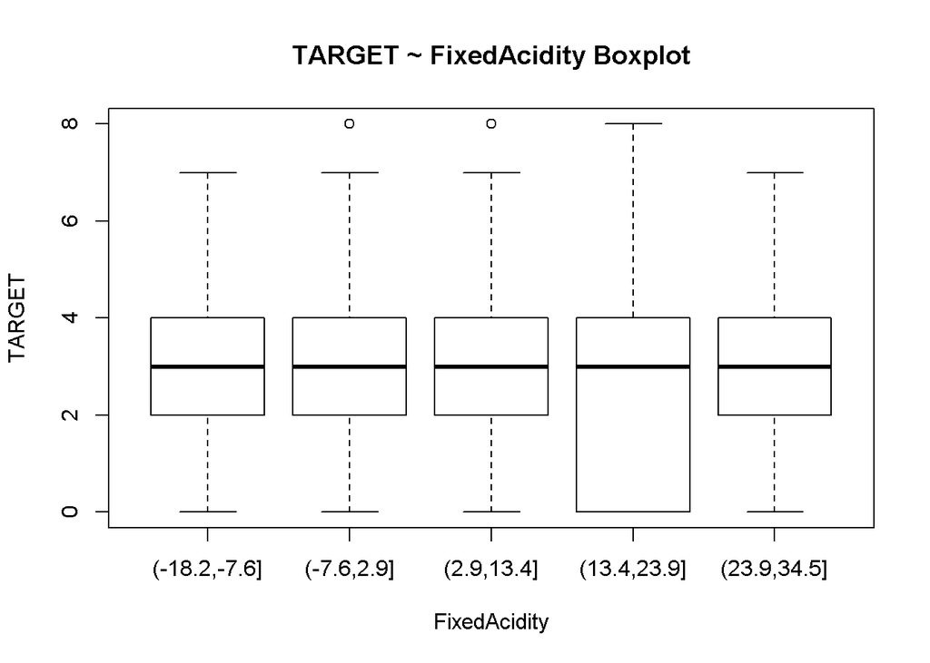

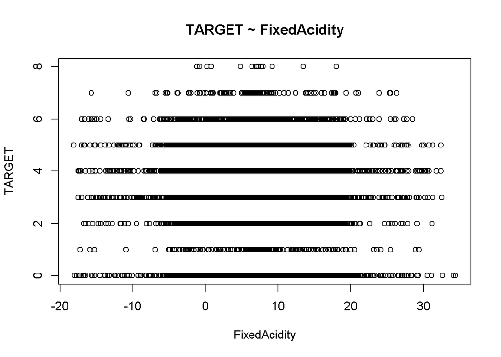

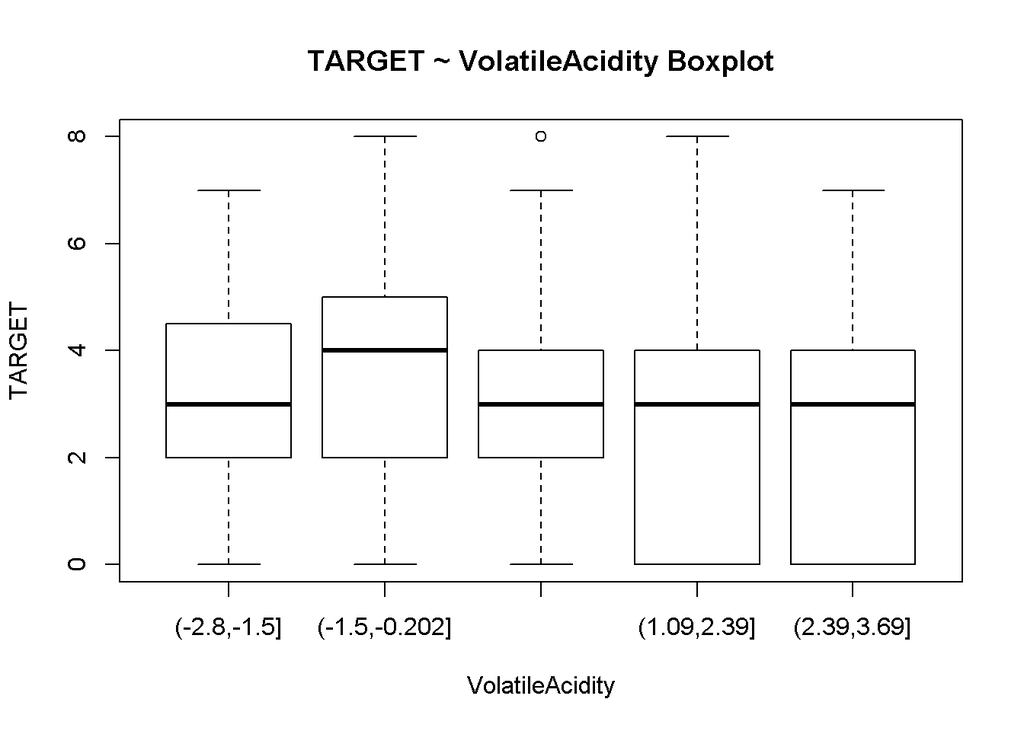

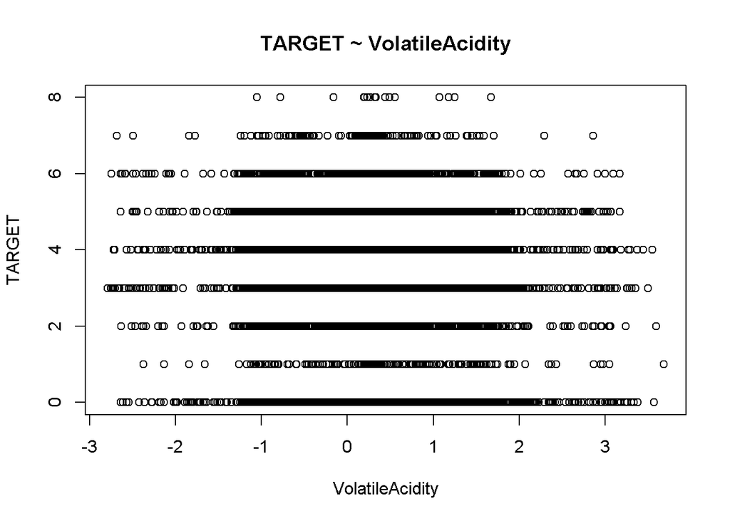

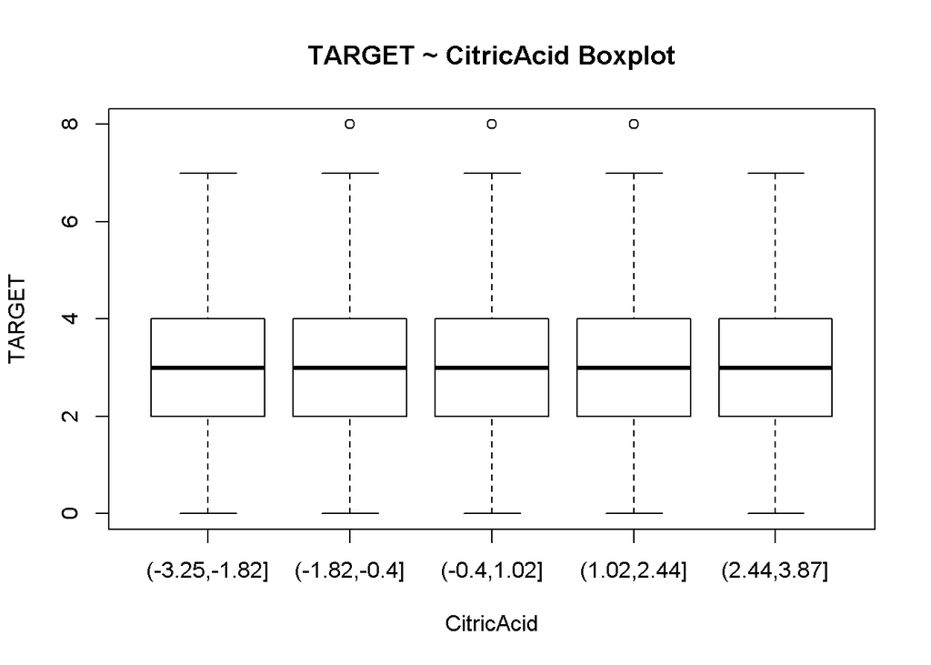

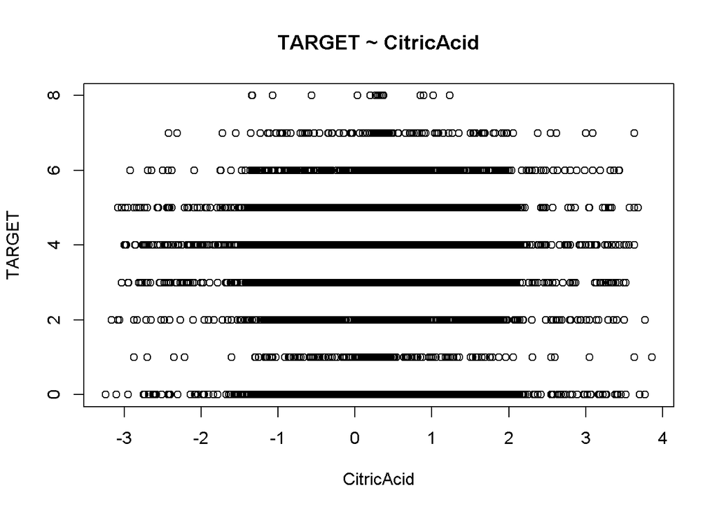

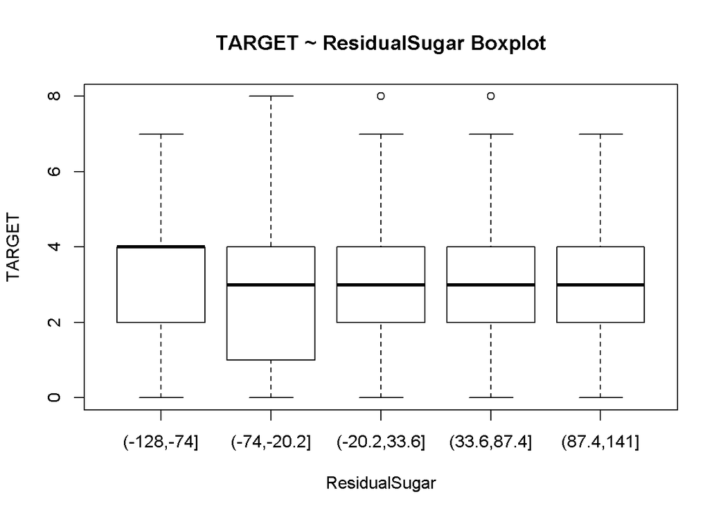

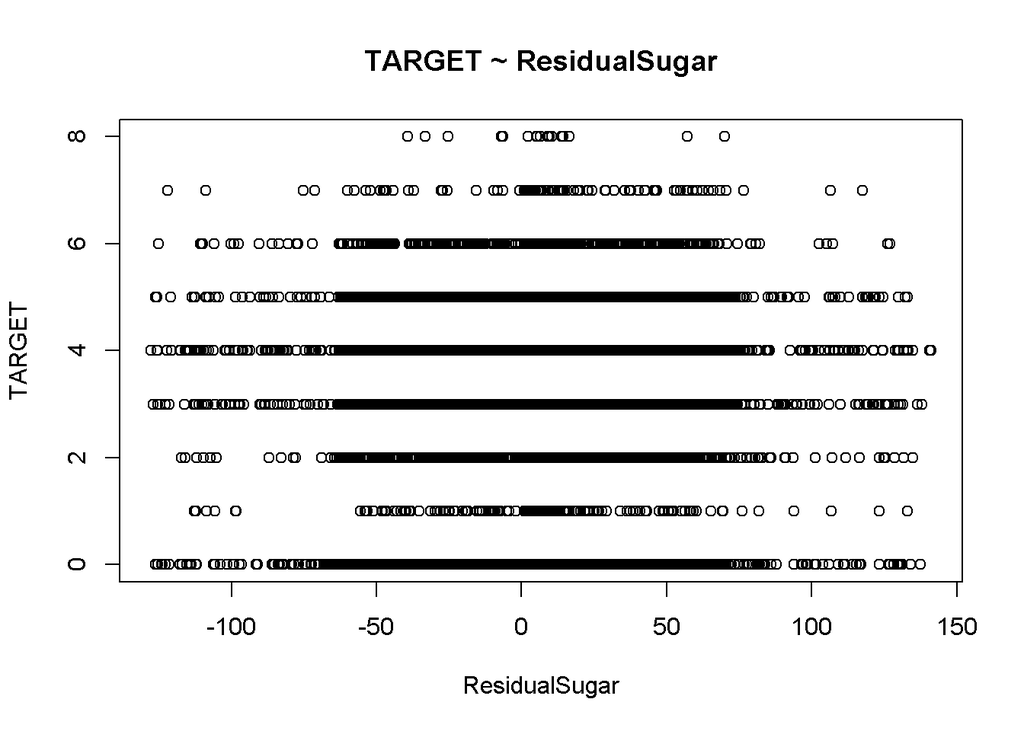

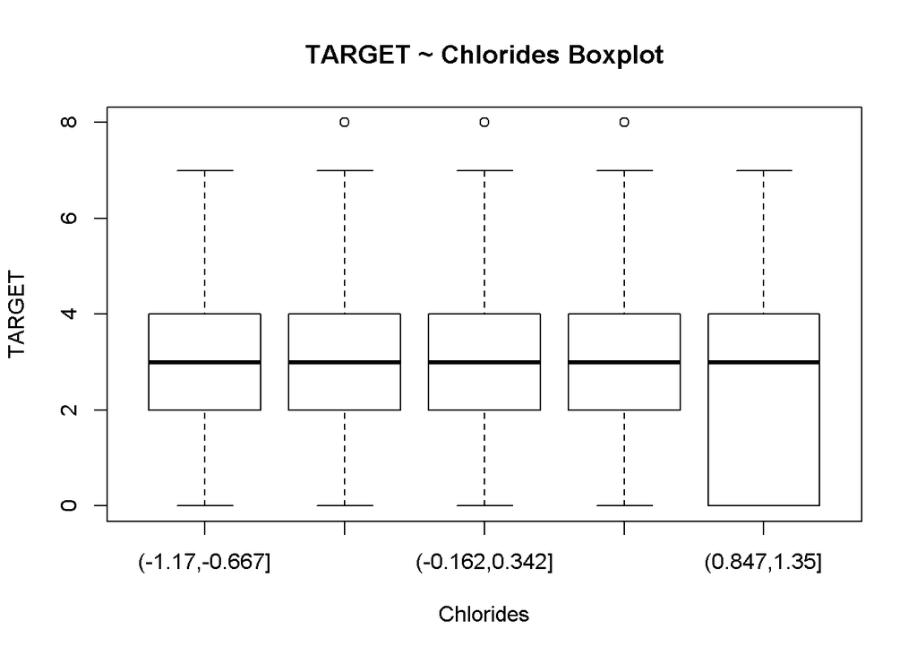

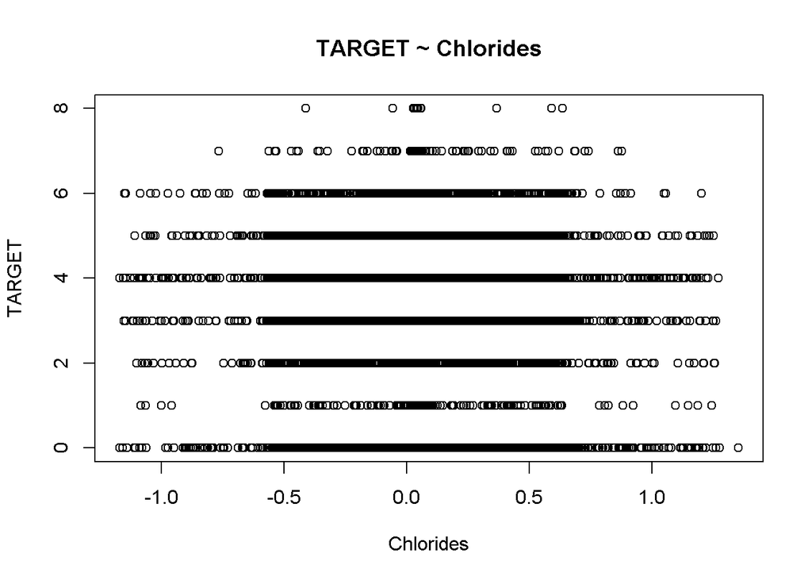

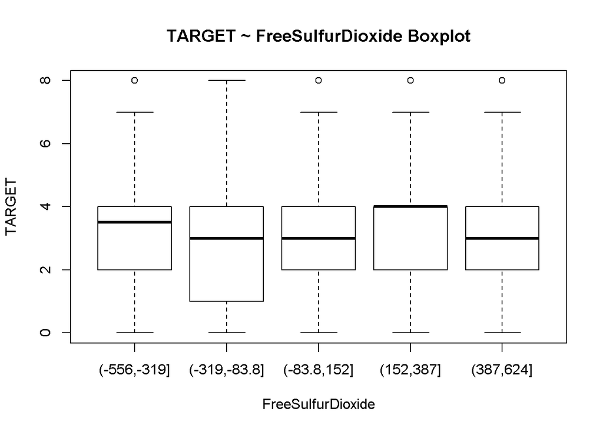

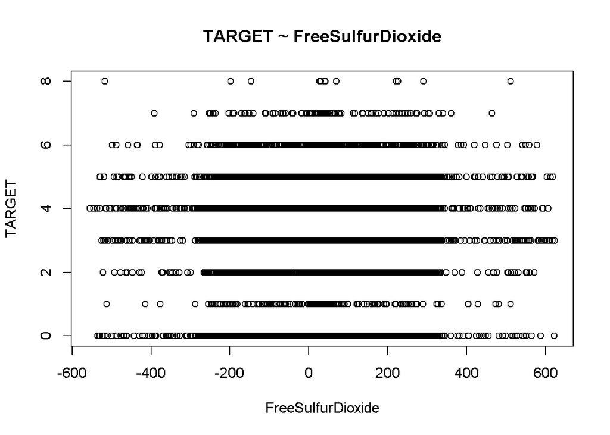

[14 more figures not shown]

```r
numResponse <- function(col,d){
    data <- d
    data <- data[order(data[,col]),c(col,target_lm)]
    x <- data[,col]
    y <- data[,target_lm]

    plot(y~cut(x,5), main=paste0("TARGET ~ ",col," Boxplot"),xlab=col, ylab="TARGET")
    plot(y~x, main=paste0("TARGET ~ ",col),xlab=col, ylab="TARGET")

}


sapply(inputs_num,function(x){numResponse(x,training_trans)})
```

```r
#sapply(inputs_num,function(x){numResponse(x,evaluation_trans)})
```

##### **TARGET_NUM**

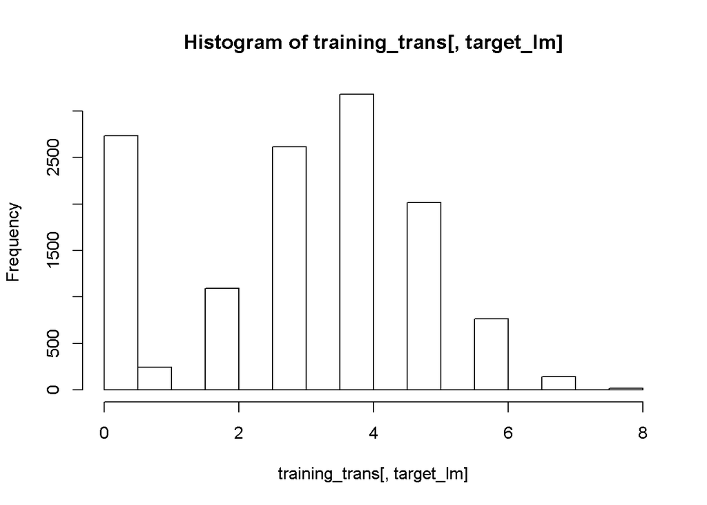

```r
hist(training_trans[,target_lm])
```

##### **Transformations Implementation**

Numerical Transformations:

- Cap AcidicIndex at 11.8

```r
# Cap values

d<- training_trans
capColumns <- function(d){
  outputCols<- colnames(d)


  #* Cap AcidicIndex at 11.8
  d[d$AcidIndex <0, 'AcidIndex'] <- 0
  d[d$AcidIndex >=11.8, 'AcidIndex'] <- 11.8

  d

}

training_trans <- capColumns(training_trans)
evaluation_trans <- capColumns(evaluation_trans)
```

#### Final summary

```r
summary <- describe(training_trans[,c(target,inputs)])[,c("n","mean","sd","median","min","max")]
summary$completeness <- summary$n/nrow(training_trans)
summary$cv <- 100*summary$sd/summary$mean

kable(summary)
```

|  | n | mean | sd | median | min | max | completeness | cv |
| --- | --- | --- | --- | --- | --- | --- | --- | --- |
| TARGET | 12795 | 3.0290739 | 1.9263682 | 3.00000 | 0.00000 | 8.00000 | 1 | 63.595948 |
| STARS_1_BIN | 12795 | 0.2377491 | 0.4257213 | 0.00000 | 0.00000 | 1.00000 | 1 | 179.063257 |
| STARS_2_BIN | 12795 | 0.2790152 | 0.4485326 | 0.00000 | 0.00000 | 1.00000 | 1 | 160.755578 |
| STARS_3_BIN | 12795 | 0.1728800 | 0.3781583 | 0.00000 | 0.00000 | 1.00000 | 1 | 218.740303 |
| STARS_4_BIN | 12795 | 0.0478312 | 0.2134172 | 0.00000 | 0.00000 | 1.00000 | 1 | 446.188511 |
| FixedAcidity | 12795 | 7.0757171 | 6.3176435 | 6.90000 | -18.10000 | 34.40000 | 1 | 89.286264 |
| VolatileAcidity | 12795 | 0.3241039 | 0.7840142 | 0.28000 | -2.79000 | 3.68000 | 1 | 241.902095 |
| CitricAcid | 12795 | 0.3084127 | 0.8620798 | 0.31000 | -3.24000 | 3.86000 | 1 | 279.521529 |
| ResidualSugar | 12795 | 5.3456155 | 32.9284864 | 3.90000 | -127.80000 | 141.15000 | 1 | 615.990555 |
| Chlorides | 12795 | 0.0543826 | 0.3104312 | 0.04600 | -1.17100 | 1.35100 | 1 | 570.828415 |
| FreeSulfurDioxide | 12795 | 30.8028136 | 144.9056039 | 30.00000 | -555.00000 | 623.00000 | 1 | 470.429766 |
| TotalSulfurDioxide | 12795 | 120.8360688 | 225.6479386 | 123.00000 | -823.00000 | 1057.00000 | 1 | 186.738894 |
| Density | 12795 | 0.9942027 | 0.0265376 | 0.99449 | 0.88809 | 1.09924 | 1 | 2.669239 |
| pH | 12795 | 3.2073927 | 0.6691138 | 3.20000 | 0.48000 | 6.13000 | 1 | 20.861612 |
| Sulphates | 12795 | 0.5245479 | 0.8869918 | 0.50000 | -3.13000 | 4.24000 | 1 | 169.096450 |
| Alcohol | 12795 | 10.4846820 | 3.6314931 | 10.40000 | -4.70000 | 26.50000 | 1 | 34.636178 |
| LabelAppeal | 12795 | -0.0090660 | 0.8910892 | 0.00000 | -2.00000 | 2.00000 | 1 | -9828.868025 |
| AcidIndex | 12795 | 7.7496835 | 1.2298857 | 8.00000 | 4.00000 | 11.80000 | 1 | 15.870141 |

```r
#head(training_trans)
#summary(training_trans)
```